Note

Go to the end to download the full example code or to run this example in your browser via JupyterLite or Binder.

# Release Highlights for scikit-learn 1.1

We are pleased to announce the release of scikit-learn 1.1! Many bug fixes and improvements were added, as well as some new key features. We detail below a few of the major features of this release. **For an exhaustive list of all the changes**, please refer to the [release notes](https://scikit-learn.org/1.9/whats_new/v1.1.html#release-notes-1-1).

To install the latest version (with pip):

```
pip install --upgrade scikit-learn
```

or with conda:

```
conda install -c conda-forge scikit-learn
```

## Quantile loss in HistGradientBoostingRegressor

`HistGradientBoostingRegressor` can model quantiles with `loss="quantile"` and the new parameter `quantile`.

```
import matplotlib.pyplot as plt
import numpy as np

from sklearn.ensemble import HistGradientBoostingRegressor

# Simple regression function for X * cos(X)
rng = np.random.RandomState(42)
X_1d = np.linspace(0, 10, num=2000)
X = X_1d.reshape(-1, 1)
y = X_1d * np.cos(X_1d) + rng.normal(scale=X_1d / 3)

quantiles = [0.95, 0.5, 0.05]
parameters = dict(loss="quantile", max_bins=32, max_iter=50)
hist_quantiles = {
    f"quantile={quantile:.2f}": HistGradientBoostingRegressor(
        **parameters, quantile=quantile
    ).fit(X, y)
    for quantile in quantiles
}

fig, ax = plt.subplots()
ax.plot(X_1d, y, "o", alpha=0.5, markersize=1)
for quantile, hist in hist_quantiles.items():
    ax.plot(X_1d, hist.predict(X), label=quantile)
_ = ax.legend(loc="lower left")
```

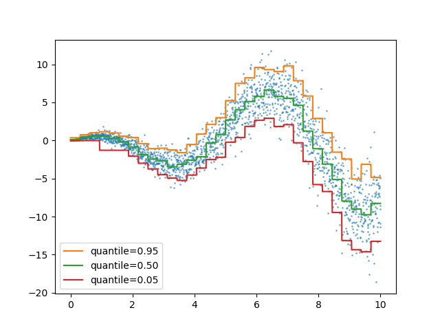

For a usecase example, see Features in Histogram Gradient Boosting Trees

## `get_feature_names_out` Available in all Transformers

get_feature_names_out is now available in all transformers, thereby concluding the implementation of [SLEP007](https://scikit-learn-enhancement-proposals.readthedocs.io/en/latest/slep007/proposal.html). This enables `Pipeline` to construct the output feature names for more complex pipelines:

```
from sklearn.compose import ColumnTransformer
from sklearn.datasets import fetch_openml
from sklearn.feature_selection import SelectKBest
from sklearn.impute import SimpleImputer
from sklearn.linear_model import LogisticRegression
from sklearn.pipeline import make_pipeline
from sklearn.preprocessing import OneHotEncoder, StandardScaler

X, y = fetch_openml(
    "titanic", version=1, as_frame=True, return_X_y=True, parser="pandas"
)
numeric_features = ["age", "fare"]
numeric_transformer = make_pipeline(SimpleImputer(strategy="median"), StandardScaler())
categorical_features = ["embarked", "pclass"]

preprocessor = ColumnTransformer(
    [
        ("num", numeric_transformer, numeric_features),
        (
            "cat",
            OneHotEncoder(handle_unknown="ignore", sparse_output=False),
            categorical_features,
        ),
    ],
    verbose_feature_names_out=False,
)
log_reg = make_pipeline(preprocessor, SelectKBest(k=7), LogisticRegression())
log_reg.fit(X, y)
```

```
Pipeline(steps=[('columntransformer',
                 ColumnTransformer(transformers=[('num',
                                                  Pipeline(steps=[('simpleimputer',
                                                                   SimpleImputer(strategy='median')),
                                                                  ('standardscaler',
                                                                   StandardScaler())]),
                                                  ['age', 'fare']),
                                                 ('cat',
                                                  OneHotEncoder(handle_unknown='ignore',
                                                                sparse_output=False),
                                                  ['embarked', 'pclass'])],
                                   verbose_feature_names_out=False)),
                ('selectkbest', SelectKBest(k=7)),
                ('logisticregression', LogisticRegression())])
```

Here we slice the pipeline to include all the steps but the last one. The output feature names of this pipeline slice are the features put into logistic regression. These names correspond directly to the coefficients in the logistic regression:

```
import pandas as pd

log_reg_input_features = log_reg[:-1].get_feature_names_out()
pd.Series(log_reg[-1].coef_.ravel(), index=log_reg_input_features).plot.bar()
plt.tight_layout()
```

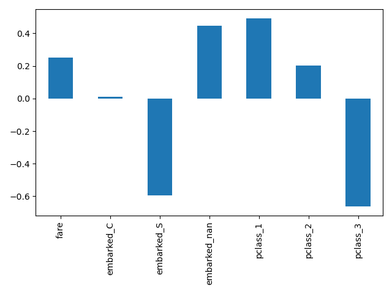

## Grouping infrequent categories in OneHotEncoder

`OneHotEncoder` supports aggregating infrequent categories into a single output for each feature. The parameters to enable the gathering of infrequent categories are `min_frequency` and `max_categories`. See the User Guide for more details.

```
import numpy as np

from sklearn.preprocessing import OneHotEncoder

X = np.array(
    [["dog"] * 5 + ["cat"] * 20 + ["rabbit"] * 10 + ["snake"] * 3], dtype=object
).T
enc = OneHotEncoder(min_frequency=6, sparse_output=False).fit(X)
enc.infrequent_categories_
```

```
[array(['dog', 'snake'], dtype=object)]
```

Since dog and snake are infrequent categories, they are grouped together when transformed:

```
encoded = enc.transform(np.array([["dog"], ["snake"], ["cat"], ["rabbit"]]))
pd.DataFrame(encoded, columns=enc.get_feature_names_out())
```

|  | x0_cat | x0_rabbit | x0_infrequent_sklearn |
| --- | --- | --- | --- |
| 0 | 0.0 | 0.0 | 1.0 |
| 1 | 0.0 | 0.0 | 1.0 |
| 2 | 1.0 | 0.0 | 0.0 |
| 3 | 0.0 | 1.0 | 0.0 |

## Performance improvements

Reductions on pairwise distances for dense float64 datasets has been refactored to better take advantage of non-blocking thread parallelism. For example, `neighbors.NearestNeighbors.kneighbors` and `neighbors.NearestNeighbors.radius_neighbors` can respectively be up to ×20 and ×5 faster than previously. In summary, the following functions and estimators now benefit from improved performance:

- `metrics.pairwise_distances_argmin`
- `metrics.pairwise_distances_argmin_min`
- `cluster.AffinityPropagation`
- `cluster.Birch`
- `cluster.MeanShift`
- `cluster.OPTICS`
- `cluster.SpectralClustering`
- `feature_selection.mutual_info_regression`
- `neighbors.KNeighborsClassifier`
- `neighbors.KNeighborsRegressor`
- `neighbors.RadiusNeighborsClassifier`
- `neighbors.RadiusNeighborsRegressor`
- `neighbors.LocalOutlierFactor`
- `neighbors.NearestNeighbors`
- `manifold.Isomap`
- `manifold.LocallyLinearEmbedding`
- `manifold.TSNE`
- `manifold.trustworthiness`
- `semi_supervised.LabelPropagation`
- `semi_supervised.LabelSpreading`

To know more about the technical details of this work, you can read [this suite of blog posts](https://blog.scikit-learn.org/technical/performances/).

Moreover, the computation of loss functions has been refactored using Cython resulting in performance improvements for the following estimators:

- `linear_model.LogisticRegression`
- `linear_model.GammaRegressor`
- `linear_model.PoissonRegressor`
- `linear_model.TweedieRegressor`

## MiniBatchNMF: an online version of NMF

The new class `MiniBatchNMF` implements a faster but less accurate version of non-negative matrix factorization (`NMF`). `MiniBatchNMF` divides the data into mini-batches and optimizes the NMF model in an online manner by cycling over the mini-batches, making it better suited for large datasets. In particular, it implements `partial_fit`, which can be used for online learning when the data is not readily available from the start, or when the data does not fit into memory.

```
import numpy as np

from sklearn.decomposition import MiniBatchNMF

rng = np.random.RandomState(0)
n_samples, n_features, n_components = 10, 10, 5
true_W = rng.uniform(size=(n_samples, n_components))
true_H = rng.uniform(size=(n_components, n_features))
X = true_W @ true_H

nmf = MiniBatchNMF(n_components=n_components, random_state=0)

for _ in range(10):
    nmf.partial_fit(X)

W = nmf.transform(X)
H = nmf.components_
X_reconstructed = W @ H

print(
    "relative reconstruction error: ",
    f"{np.sum((X - X_reconstructed) ** 2) / np.sum(X**2):.5f}",
)
```

```
relative reconstruction error:  0.00364
```

## BisectingKMeans: divide and cluster

The new class `BisectingKMeans` is a variant of `KMeans`, using divisive hierarchical clustering. Instead of creating all centroids at once, centroids are picked progressively based on a previous clustering: a cluster is split into two new clusters repeatedly until the target number of clusters is reached, giving a hierarchical structure to the clustering.

```
import matplotlib.pyplot as plt

from sklearn.cluster import BisectingKMeans, KMeans
from sklearn.datasets import make_blobs

X, _ = make_blobs(n_samples=1000, centers=2, random_state=0)

km = KMeans(n_clusters=5, random_state=0, n_init="auto").fit(X)
bisect_km = BisectingKMeans(n_clusters=5, random_state=0).fit(X)

fig, ax = plt.subplots(1, 2, figsize=(10, 5))
ax[0].scatter(X[:, 0], X[:, 1], s=10, c=km.labels_)
ax[0].scatter(km.cluster_centers_[:, 0], km.cluster_centers_[:, 1], s=20, c="r")
ax[0].set_title("KMeans")

ax[1].scatter(X[:, 0], X[:, 1], s=10, c=bisect_km.labels_)
ax[1].scatter(
    bisect_km.cluster_centers_[:, 0], bisect_km.cluster_centers_[:, 1], s=20, c="r"
)
_ = ax[1].set_title("BisectingKMeans")
```

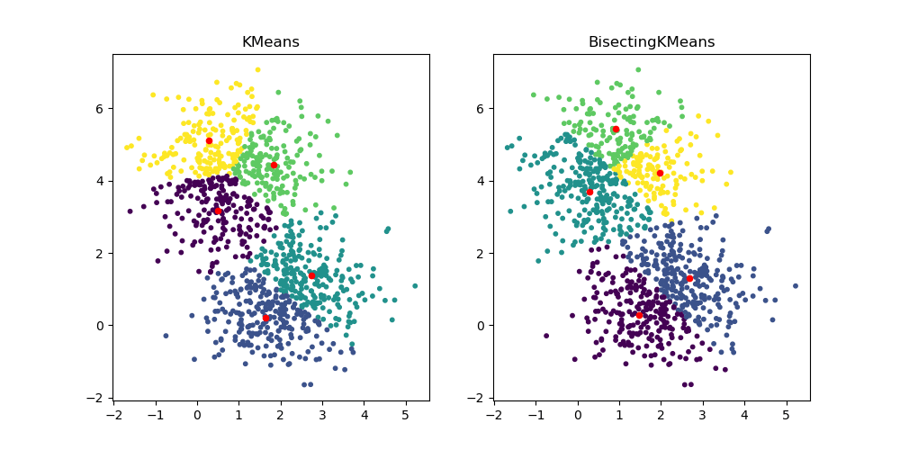

**Total running time of the script:** (0 minutes 0.890 seconds)

[figure not shown]

[`Download Jupyter notebook: plot_release_highlights_1_1_0.ipynb`](https://scikit-learn.org/1.9/_downloads/68fdea23e50d165632d4bd4e36453cd5/plot_release_highlights_1_1_0.ipynb)

[`Download Python source code: plot_release_highlights_1_1_0.py`](https://scikit-learn.org/1.9/_downloads/4cf0456267ced0f869a458ef4776d4c5/plot_release_highlights_1_1_0.py)

[`Download zipped: plot_release_highlights_1_1_0.zip`](https://scikit-learn.org/1.9/_downloads/a4ca19d099be76c1c7cbb53108c7b00b/plot_release_highlights_1_1_0.zip)

#### Related examples

Release Highlights for scikit-learn 1.0

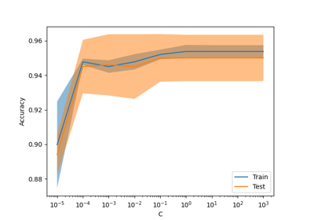

Release Highlights for scikit-learn 1.3

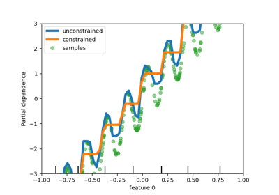

Release Highlights for scikit-learn 0.23

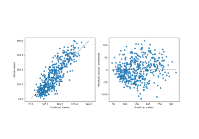

Release Highlights for scikit-learn 1.2

© 2007–2026 The scikit-learn developers  
Licensed under the 3-clause BSD License.  
https://scikit-learn.org/1.9/auto_examples/release_highlights/plot_release_highlights_1_1_0.html